# CNP Nutrition Signature Validation

# Omega-3

## Omega_3_FattyAcids

*Source:* Curated (Signatures/NutSignaturesList.R)

*Panel:* Omega-3 · *Training set:* GSE12375 PBMC · human EPA/DHA vs MUFA, 6 mo · *Signature size:* 5 genes · *Score direction learned in training:* GSVA higher in case; ssGSEA higher in case; PLAGE higher in case; zScore higher in case; singscore higher in case

| Dataset | Species | Signature genes | Found in data | Coverage |
| --- | --- | --- | --- | --- |
| GSE12375 PBMC · human EPA/DHA vs MUFA, 6 mo | Homo sapiens | 5 | 4 | 80% |
| GSE48368 PBMC · human fish oil vs HOSO, 7 wk | Homo sapiens | 5 | 5 | 100% |
| GSE29680 PBMC · Alzheimer patients n-3 vs placebo, 6 mo | Homo sapiens | 5 | 4 | 80% |

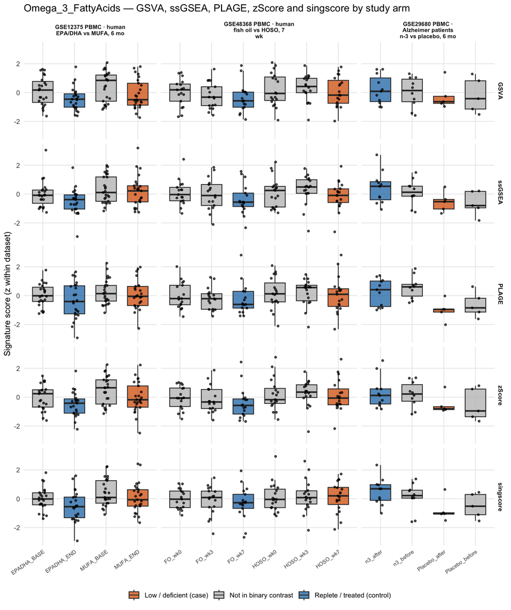

**ANOVA p-values.** *All arms* = one-way ANOVA across every study arm; *case vs control* = group effect after the listed covariates.

| Dataset | Role | Adjusted for | p (all arms) / p (case vs control) GSVA | p (all arms) / p (case vs control) ssGSEA | p (all arms) / p (case vs control) PLAGE | p (all arms) / p (case vs control) zScore | p (all arms) / p (case vs control) singscore |
| --- | --- | --- | --- | --- | --- | --- | --- |
| GSE12375 PBMC · human EPA/DHA vs MUFA, 6 mo | Training | — | 0.022 / 0.229 | 0.022 / 0.020 | 0.178 / 0.178 | 0.008 / 0.111 | 0.010 / 0.049 |
| GSE48368 PBMC · human fish oil vs HOSO, 7 wk | External | — | 0.303 / 0.199 | 0.510 / 0.486 | 0.648 / 0.441 | 0.388 / 0.161 | 0.701 / 0.248 |
| GSE29680 PBMC · Alzheimer patients n-3 vs placebo, 6 mo | External | — | 0.844 / 0.431 | 0.124 / 0.096 | 0.006 / 0.018 | 0.271 / 0.155 | 0.063 / 0.020 |

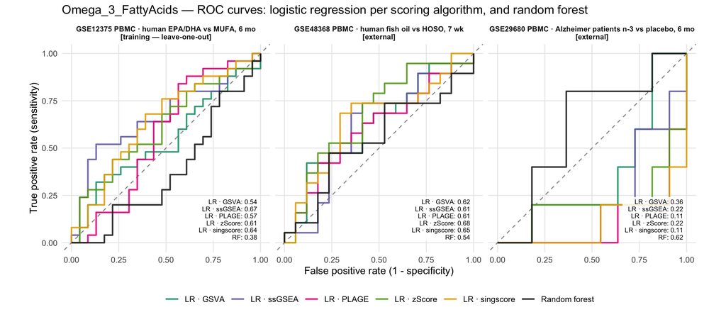

| Dataset | Validation | Model | AUC | 95% CI | Accuracy (p ≥ 0.5) | n case | n control |
| --- | --- | --- | --- | --- | --- | --- | --- |
| GSE12375 PBMC · human EPA/DHA vs MUFA, 6 mo | Internal (in-sample) | Score · GSVA | 0.57 | 0.41–0.74 | — | 25 | 23 |
|  |  | Score · ssGSEA | 0.70 | 0.54–0.85 | — | 25 | 23 |
|  |  | Score · PLAGE | 0.60 | 0.43–0.77 | — | 25 | 23 |
|  |  | Score · zScore | 0.63 | 0.47–0.79 | — | 25 | 23 |
|  |  | Score · singscore | 0.67 | 0.51–0.82 | — | 25 | 23 |
|  | Internal (LOOCV) | LR · GSVA | 0.54 | 0.38–0.71 | 0.54 | 25 | 23 |
|  |  | LR · ssGSEA | 0.67 | 0.51–0.82 | 0.62 | 25 | 23 |
|  |  | LR · PLAGE | 0.57 | 0.39–0.74 | 0.6 | 25 | 23 |
|  |  | LR · zScore | 0.61 | 0.45–0.77 | 0.56 | 25 | 23 |
|  |  | LR · singscore | 0.64 | 0.48–0.80 | 0.6 | 25 | 23 |
|  |  | Random forest | 0.38 | 0.22–0.54 | 0.4 | 25 | 23 |
|  | Internal (leave-pair-out) | LR · GSVA | 0.57 | — | — | 25 | 23 |
|  |  | LR · ssGSEA | 0.70 | — | — | 25 | 23 |
|  |  | LR · PLAGE | 0.60 | — | — | 25 | 23 |
|  |  | LR · zScore | 0.63 | — | — | 25 | 23 |
|  |  | LR · singscore | 0.67 | — | — | 25 | 23 |
|  |  | Random forest | 0.43 | — | — | 25 | 23 |
| GSE48368 PBMC · human fish oil vs HOSO, 7 wk | External | Score · GSVA | 0.62 | 0.43–0.81 | — | 19 | 17 |
|  |  | Score · ssGSEA | 0.61 | 0.41–0.80 | — | 19 | 17 |
|  |  | Score · PLAGE | 0.61 | 0.42–0.80 | — | 19 | 17 |
|  |  | Score · zScore | 0.68 | 0.50–0.86 | — | 19 | 17 |
|  |  | Score · singscore | 0.65 | 0.46–0.84 | — | 19 | 17 |
|  |  | LR · GSVA | 0.62 | 0.43–0.81 | 0.53 | 19 | 17 |
|  |  | LR · ssGSEA | 0.61 | 0.41–0.80 | 0.61 | 19 | 17 |
|  |  | LR · PLAGE | 0.61 | 0.42–0.80 | 0.61 | 19 | 17 |
|  |  | LR · zScore | 0.68 | 0.50–0.86 | 0.61 | 19 | 17 |
|  |  | LR · singscore | 0.65 | 0.46–0.84 | 0.69 | 19 | 17 |
|  |  | Random forest | 0.54 | 0.35–0.74 | 0.5 | 19 | 17 |
| GSE29680 PBMC · Alzheimer patients n-3 vs placebo, 6 mo |  | Score · GSVA | 0.36 | 0.05–0.68 | — | 5 | 11 |
|  |  | Score · ssGSEA | 0.22 | 0.00–0.46 | — | 5 | 11 |
|  |  | Score · PLAGE | 0.11 | 0.00–0.28 | — | 5 | 11 |
|  |  | Score · zScore | 0.22 | 0.00–0.54 | — | 5 | 11 |
|  |  | Score · singscore | 0.11 | 0.00–0.30 | — | 5 | 11 |
|  |  | LR · GSVA | 0.36 | 0.05–0.68 | 0.38 | 5 | 11 |
|  |  | LR · ssGSEA | 0.22 | 0.00–0.46 | 0.38 | 5 | 11 |
|  |  | LR · PLAGE | 0.11 | 0.00–0.28 | 0.31 | 5 | 11 |
|  |  | LR · zScore | 0.22 | 0.00–0.54 | 0.38 | 5 | 11 |
|  |  | LR · singscore | 0.11 | 0.00–0.30 | 0.31 | 5 | 11 |
|  |  | Random forest | 0.62 | 0.31–0.93 | 0.62 | 5 | 11 |

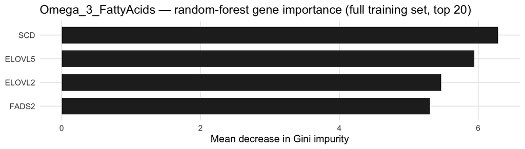

# Vitamin B1

## B1_Thiamine

*Source:* Curated (Signatures/NutSignaturesList.R)

*Panel:* Vitamin B1 · *Training set:* GSE31553 myotubes · human benfotiamine · *Signature size:* 25 genes · *Score direction learned in training:* GSVA higher in case; ssGSEA lower in case; PLAGE lower in case; zScore lower in case; singscore higher in case

| Dataset | Species | Signature genes | Found in data | Coverage |
| --- | --- | --- | --- | --- |
| GSE31553 myotubes · human benfotiamine | Homo sapiens | 25 | 19 | 76% |

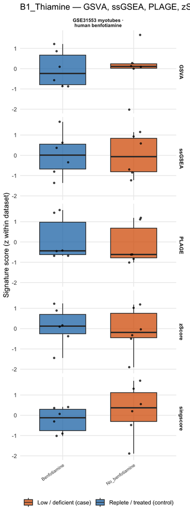

**ANOVA p-values.** *All arms* = one-way ANOVA across every study arm; *case vs control* = group effect after the listed covariates.

| Dataset | Role | Adjusted for | p (all arms) / p (case vs control) GSVA | p (all arms) / p (case vs control) ssGSEA | p (all arms) / p (case vs control) PLAGE | p (all arms) / p (case vs control) zScore | p (all arms) / p (case vs control) singscore |
| --- | --- | --- | --- | --- | --- | --- | --- |
| GSE31553 myotubes · human benfotiamine | Training | glucose, donor | 0.942 / 0.940 | 0.943 / 0.945 | 0.674 / 0.013 | 0.764 / 0.778 | 0.450 / 0.464 |

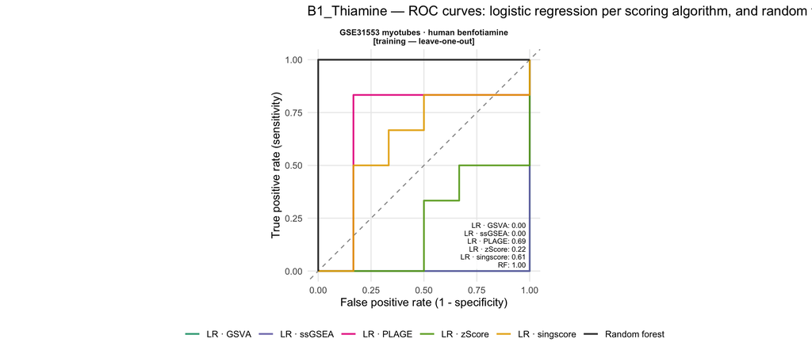

| Dataset | Validation | Model | AUC | 95% CI | Accuracy (p ≥ 0.5) | n case | n control |
| --- | --- | --- | --- | --- | --- | --- | --- |
| GSE31553 myotubes · human benfotiamine | Internal (in-sample) | Score · GSVA | 0.58 | 0.19–0.97 | — | 6 | 6 |
|  |  | Score · ssGSEA | 0.53 | 0.13–0.92 | — | 6 | 6 |
|  |  | Score · PLAGE | 0.97 | 0.90–1.00 | — | 6 | 6 |
|  |  | Score · zScore | 0.56 | 0.18–0.93 | — | 6 | 6 |
|  |  | Score · singscore | 0.67 | 0.32–1.00 | — | 6 | 6 |
|  | Internal (LOOCV) | LR · GSVA | 0.00 | 0.00–0.00 | 0 | 6 | 6 |
|  |  | LR · ssGSEA | 0.00 | 0.00–0.00 | 0.08 | 6 | 6 |
|  |  | LR · PLAGE | 0.69 | 0.31–1.00 | 0.83 | 6 | 6 |
|  |  | LR · zScore | 0.22 | 0.00–0.51 | 0.42 | 6 | 6 |
|  |  | LR · singscore | 0.61 | 0.24–0.98 | 0.58 | 6 | 6 |
|  |  | Random forest | 1.00 | 1.00–1.00 | 0.92 | 6 | 6 |
|  | Internal (leave-pair-out) | LR · GSVA | 0.06 | — | — | 6 | 6 |
|  |  | LR · ssGSEA | 0.08 | — | — | 6 | 6 |
|  |  | LR · PLAGE | 0.83 | — | — | 6 | 6 |
|  |  | LR · zScore | 0.33 | — | — | 6 | 6 |
|  |  | LR · singscore | 0.67 | — | — | 6 | 6 |
|  |  | Random forest | 0.97 | — | — | 6 | 6 |

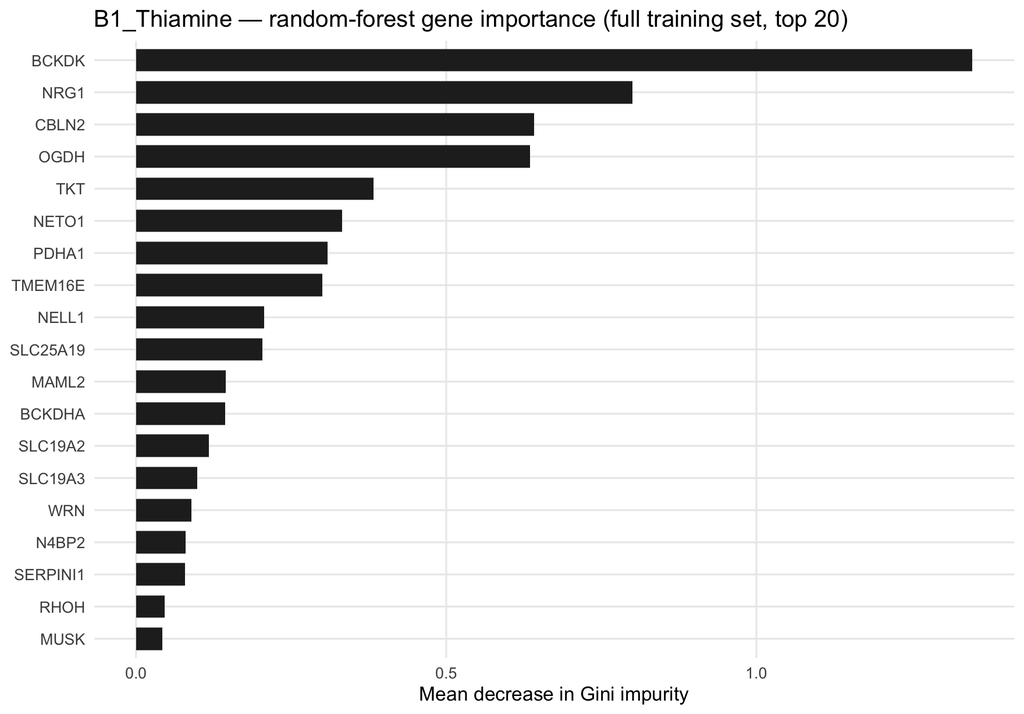

# Vitamin B3

## B3_Niacin

*Source:* Curated (Signatures/NutSignaturesList.R)

*Panel:* Vitamin B3 · *Training set:* GSE345595 liver · mouse niacin-free diet · *Signature size:* 3 genes · *Score direction learned in training:* GSVA lower in case; ssGSEA lower in case; PLAGE lower in case; zScore lower in case; singscore lower in case

| Dataset | Species | Signature genes | Found in data | Coverage |
| --- | --- | --- | --- | --- |
| GSE345595 liver · mouse niacin-free diet | Mus musculus | 3 | 2 | 67% |
| GSE345344 liver · mouse niacin-free diet / recovery | Mus musculus | 3 | 2 | 67% |
| GSE300498 intestine · mouse tryptophan/niacin-free diet | Mus musculus | 3 | 2 | 67% |
| GSE92499 liver · mouse nicotinamide supplementation | Mus musculus | 3 | 2 | 67% |

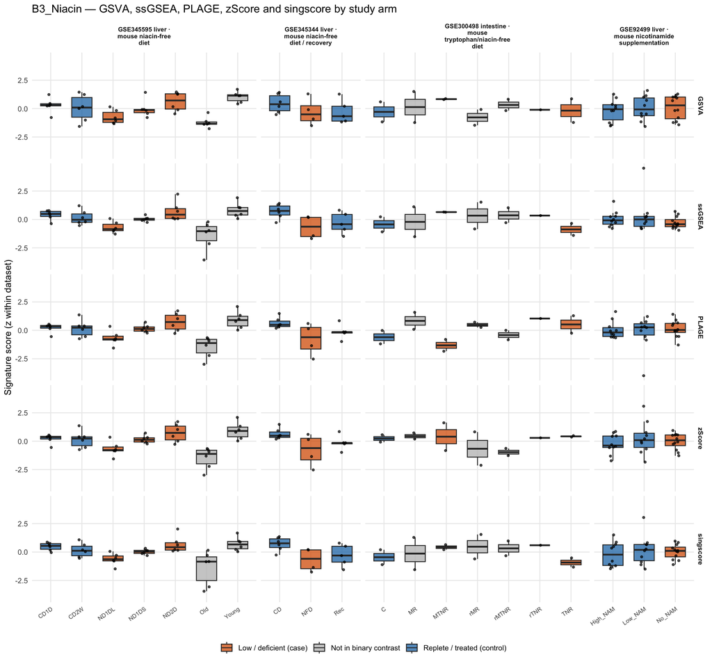

**ANOVA p-values.** *All arms* = one-way ANOVA across every study arm; *case vs control* = group effect after the listed covariates.

| Dataset | Role | Adjusted for | p (all arms) / p (case vs control) GSVA | p (all arms) / p (case vs control) ssGSEA | p (all arms) / p (case vs control) PLAGE | p (all arms) / p (case vs control) zScore | p (all arms) / p (case vs control) singscore |
| --- | --- | --- | --- | --- | --- | --- | --- |
| GSE345595 liver · mouse niacin-free diet | Training | doxycycline | 1.4e-04 / 0.437 | 3.5e-05 / 0.277 | 8.4e-06 / 0.687 | 8.4e-06 / 0.687 | 1.7e-04 / 0.156 |
| GSE345344 liver · mouse niacin-free diet / recovery | External | — | 0.395 / 0.495 | 0.055 / 0.112 | 0.070 / 0.063 | 0.070 / 0.063 | 0.060 / 0.112 |
| GSE300498 intestine · mouse tryptophan/niacin-free diet | External | strain | 0.890 / 0.466 | 0.854 / 0.729 | 0.205 / 0.871 | 0.789 / 0.799 | 0.845 / 0.789 |
| GSE92499 liver · mouse nicotinamide supplementation | External | diet | 0.820 / 0.671 | 0.425 / 0.248 | 0.754 / 0.558 | 0.548 / 0.927 | 0.724 / 0.903 |

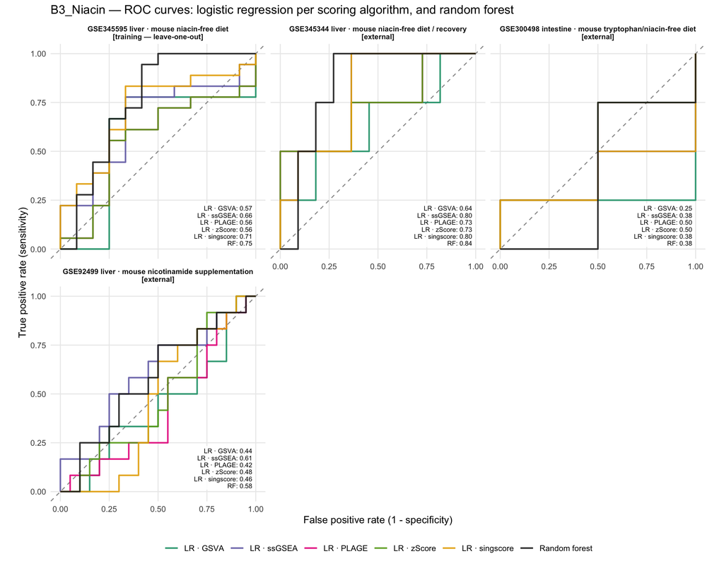

| Dataset | Validation | Model | AUC | 95% CI | Accuracy (p ≥ 0.5) | n case | n control |
| --- | --- | --- | --- | --- | --- | --- | --- |
| GSE345595 liver · mouse niacin-free diet | Internal (in-sample) | Score · GSVA | 0.64 | 0.42–0.86 | — | 18 | 12 |
|  |  | Score · ssGSEA | 0.68 | 0.47–0.88 | — | 18 | 12 |
|  |  | Score · PLAGE | 0.61 | 0.40–0.82 | — | 18 | 12 |
|  |  | Score · zScore | 0.61 | 0.40–0.82 | — | 18 | 12 |
|  |  | Score · singscore | 0.74 | 0.55–0.93 | — | 18 | 12 |
|  | Internal (LOOCV) | LR · GSVA | 0.57 | 0.33–0.82 | 0.7 | 18 | 12 |
|  |  | LR · ssGSEA | 0.66 | 0.45–0.87 | 0.73 | 18 | 12 |
|  |  | LR · PLAGE | 0.56 | 0.34–0.78 | 0.6 | 18 | 12 |
|  |  | LR · zScore | 0.56 | 0.34–0.78 | 0.6 | 18 | 12 |
|  |  | LR · singscore | 0.71 | 0.51–0.91 | 0.73 | 18 | 12 |
|  |  | Random forest | 0.75 | 0.55–0.96 | 0.7 | 18 | 12 |
|  | Internal (leave-pair-out) | LR · GSVA | 0.64 | — | — | 18 | 12 |
|  |  | LR · ssGSEA | 0.68 | — | — | 18 | 12 |
|  |  | LR · PLAGE | 0.61 | — | — | 18 | 12 |
|  |  | LR · zScore | 0.61 | — | — | 18 | 12 |
|  |  | LR · singscore | 0.74 | — | — | 18 | 12 |
|  |  | Random forest | 0.79 | — | — | 18 | 12 |
| GSE345344 liver · mouse niacin-free diet / recovery | External | Score · GSVA | 0.64 | 0.26–1.00 | — | 4 | 11 |
|  |  | Score · ssGSEA | 0.80 | 0.54–1.00 | — | 4 | 11 |
|  |  | Score · PLAGE | 0.73 | 0.36–1.00 | — | 4 | 11 |
|  |  | Score · zScore | 0.73 | 0.36–1.00 | — | 4 | 11 |
|  |  | Score · singscore | 0.80 | 0.54–1.00 | — | 4 | 11 |
|  |  | LR · GSVA | 0.64 | 0.26–1.00 | 0.6 | 4 | 11 |
|  |  | LR · ssGSEA | 0.80 | 0.54–1.00 | 0.6 | 4 | 11 |
|  |  | LR · PLAGE | 0.73 | 0.36–1.00 | 0.6 | 4 | 11 |
|  |  | LR · zScore | 0.73 | 0.36–1.00 | 0.6 | 4 | 11 |
|  |  | LR · singscore | 0.80 | 0.54–1.00 | 0.6 | 4 | 11 |
|  |  | Random forest | 0.84 | 0.63–1.00 | 0.73 | 4 | 11 |
| GSE300498 intestine · mouse tryptophan/niacin-free diet |  | Score · GSVA | 0.25 | 0.00–0.74 | — | 4 | 2 |
|  |  | Score · ssGSEA | 0.38 | 0.00–0.90 | — | 4 | 2 |
|  |  | Score · PLAGE | 0.50 | 0.00–1.00 | — | 4 | 2 |
|  |  | Score · zScore | 0.50 | 0.00–1.00 | — | 4 | 2 |
|  |  | Score · singscore | 0.38 | 0.00–0.90 | — | 4 | 2 |
|  |  | LR · GSVA | 0.25 | 0.00–0.74 | 0.33 | 4 | 2 |
|  |  | LR · ssGSEA | 0.38 | 0.00–0.90 | 0.5 | 4 | 2 |
|  |  | LR · PLAGE | 0.50 | 0.00–1.00 | 0.5 | 4 | 2 |
|  |  | LR · zScore | 0.50 | 0.00–1.00 | 0.5 | 4 | 2 |
|  |  | LR · singscore | 0.38 | 0.00–0.90 | 0.5 | 4 | 2 |
|  |  | Random forest | 0.38 | 0.00–1.00 | 0.67 | 4 | 2 |
| GSE92499 liver · mouse nicotinamide supplementation |  | Score · GSVA | 0.44 | 0.22–0.65 | — | 12 | 20 |
|  |  | Score · ssGSEA | 0.61 | 0.40–0.82 | — | 12 | 20 |
|  |  | Score · PLAGE | 0.42 | 0.22–0.63 | — | 12 | 20 |
|  |  | Score · zScore | 0.48 | 0.27–0.69 | — | 12 | 20 |
|  |  | Score · singscore | 0.46 | 0.25–0.66 | — | 12 | 20 |
|  |  | LR · GSVA | 0.44 | 0.22–0.65 | 0.5 | 12 | 20 |
|  |  | LR · ssGSEA | 0.61 | 0.40–0.82 | 0.59 | 12 | 20 |
|  |  | LR · PLAGE | 0.42 | 0.22–0.63 | 0.44 | 12 | 20 |
|  |  | LR · zScore | 0.48 | 0.27–0.69 | 0.47 | 12 | 20 |
|  |  | LR · singscore | 0.46 | 0.25–0.66 | 0.5 | 12 | 20 |
|  |  | Random forest | 0.58 | 0.37–0.79 | 0.47 | 12 | 20 |

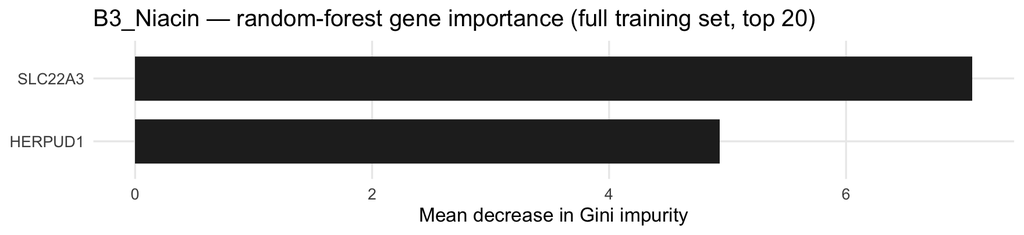

# Vitamin B5

## B5_Pantothenic Acid

*Source:* Curated (Signatures/NutSignaturesList.R)

*Panel:* Vitamin B5 · *Training set:* GSE130705 brain · mouse Pank1/2 knockout (CoA deficiency) · *Signature size:* 18 genes · *Score direction learned in training:* GSVA higher in case; ssGSEA higher in case; PLAGE higher in case; zScore higher in case; singscore higher in case

| Dataset | Species | Signature genes | Found in data | Coverage |
| --- | --- | --- | --- | --- |
| GSE130705 brain · mouse Pank1/2 knockout (CoA deficiency) | Mus musculus | 18 | 9 | 50% |
| GSE187456 Tc0 T cells · mouse coenzyme A | Mus musculus | 18 | 8 | 44% |

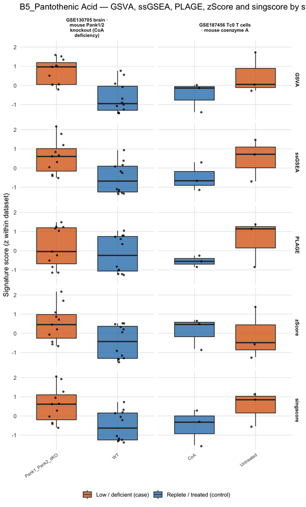

**ANOVA p-values.** *All arms* = one-way ANOVA across every study arm; *case vs control* = group effect after the listed covariates.

| Dataset | Role | Adjusted for | p (all arms) / p (case vs control) GSVA | p (all arms) / p (case vs control) ssGSEA | p (all arms) / p (case vs control) PLAGE | p (all arms) / p (case vs control) zScore | p (all arms) / p (case vs control) singscore |
| --- | --- | --- | --- | --- | --- | --- | --- |
| GSE130705 brain · mouse Pank1/2 knockout (CoA deficiency) | Training | sex, day | 1.9e-04 / 1.9e-06 | 0.005 / 7.8e-07 | 0.363 / 3.5e-04 | 0.018 / 5.1e-06 | 0.005 / 3.7e-07 |
| GSE187456 Tc0 T cells · mouse coenzyme A | External | mouse | 0.258 / 0.199 | 0.261 / 0.445 | 0.202 / 0.185 | 0.808 / 0.737 | 0.253 / 0.007 |

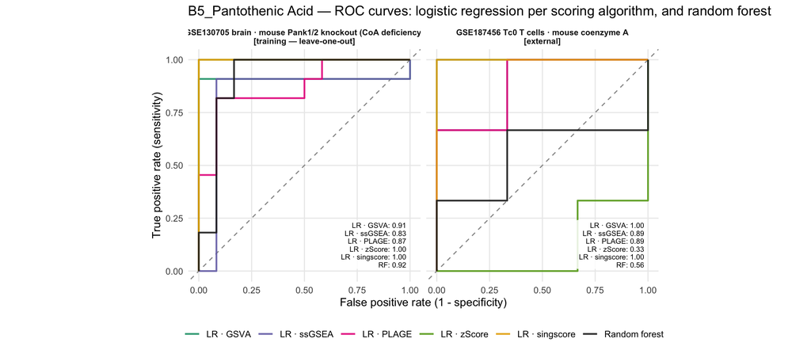

| Dataset | Validation | Model | AUC | 95% CI | Accuracy (p ≥ 0.5) | n case | n control |
| --- | --- | --- | --- | --- | --- | --- | --- |
| GSE130705 brain · mouse Pank1/2 knockout (CoA deficiency) | Internal (in-sample) | Score · GSVA | 0.98 | 0.93–1.00 | — | 11 | 12 |
|  |  | Score · ssGSEA | 0.99 | 0.97–1.00 | — | 11 | 12 |
|  |  | Score · PLAGE | 0.91 | 0.79–1.00 | — | 11 | 12 |
|  |  | Score · zScore | 1.00 | 1.00–1.00 | — | 11 | 12 |
|  |  | Score · singscore | 1.00 | 1.00–1.00 | — | 11 | 12 |
|  | Internal (LOOCV) | LR · GSVA | 0.91 | 0.73–1.00 | 0.91 | 11 | 12 |
|  |  | LR · ssGSEA | 0.83 | 0.61–1.00 | 0.91 | 11 | 12 |
|  |  | LR · PLAGE | 0.87 | 0.72–1.00 | 0.83 | 11 | 12 |
|  |  | LR · zScore | 1.00 | 1.00–1.00 | 0.96 | 11 | 12 |
|  |  | LR · singscore | 1.00 | 1.00–1.00 | 1 | 11 | 12 |
|  |  | Random forest | 0.92 | 0.78–1.00 | 0.87 | 11 | 12 |
|  | Internal (leave-pair-out) | LR · GSVA | 0.95 | — | — | 11 | 12 |
|  |  | LR · ssGSEA | 0.91 | — | — | 11 | 12 |
|  |  | LR · PLAGE | 0.91 | — | — | 11 | 12 |
|  |  | LR · zScore | 1.00 | — | — | 11 | 12 |
|  |  | LR · singscore | 1.00 | — | — | 11 | 12 |
|  |  | Random forest | 0.94 | — | — | 11 | 12 |
| GSE187456 Tc0 T cells · mouse coenzyme A | External | Score · GSVA | 1.00 | 1.00–1.00 | — | 3 | 3 |
|  |  | Score · ssGSEA | 0.89 | 0.58–1.00 | — | 3 | 3 |
|  |  | Score · PLAGE | 0.89 | 0.58–1.00 | — | 3 | 3 |
|  |  | Score · zScore | 0.33 | 0.00–0.87 | — | 3 | 3 |
|  |  | Score · singscore | 1.00 | 1.00–1.00 | — | 3 | 3 |
|  |  | LR · GSVA | 1.00 | 1.00–1.00 | 0.83 | 3 | 3 |
|  |  | LR · ssGSEA | 0.89 | 0.58–1.00 | 0.67 | 3 | 3 |
|  |  | LR · PLAGE | 0.89 | 0.58–1.00 | 0.83 | 3 | 3 |
|  |  | LR · zScore | 0.33 | 0.00–0.80 | 0.33 | 3 | 3 |
|  |  | LR · singscore | 1.00 | 1.00–1.00 | 1 | 3 | 3 |
|  |  | Random forest | 0.56 | 0.00–1.00 | 0.67 | 3 | 3 |

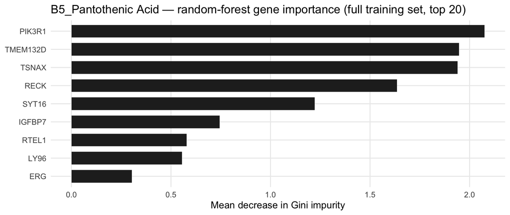

# Iron

## Iron_Homeostasis

*Source:* Curated (Signatures/NutSignaturesList.R)

*Panel:* Iron · *Training set:* GSE162493 heart · mouse iron-deficient diet · *Signature size:* 6 genes · *Score direction learned in training:* GSVA higher in case; ssGSEA higher in case; PLAGE higher in case; zScore higher in case; singscore higher in case

| Dataset | Species | Signature genes | Found in data | Coverage |
| --- | --- | --- | --- | --- |
| GSE162493 heart · mouse iron-deficient diet | Mus musculus | 6 | 6 | 100% |
| GSE157667 placenta · mouse iron deficiency | Mus musculus | 6 | 6 | 100% |
| GSE30533 liver · rat iron-deficient diet | Rattus norvegicus | 6 | 6 | 100% |
| GSE175739 whole blood · heart-failure patients | Homo sapiens | 6 | 6 | 100% |
| GSE314015 endothelial cells · human iron chelation | Homo sapiens | 6 | 6 | 100% |

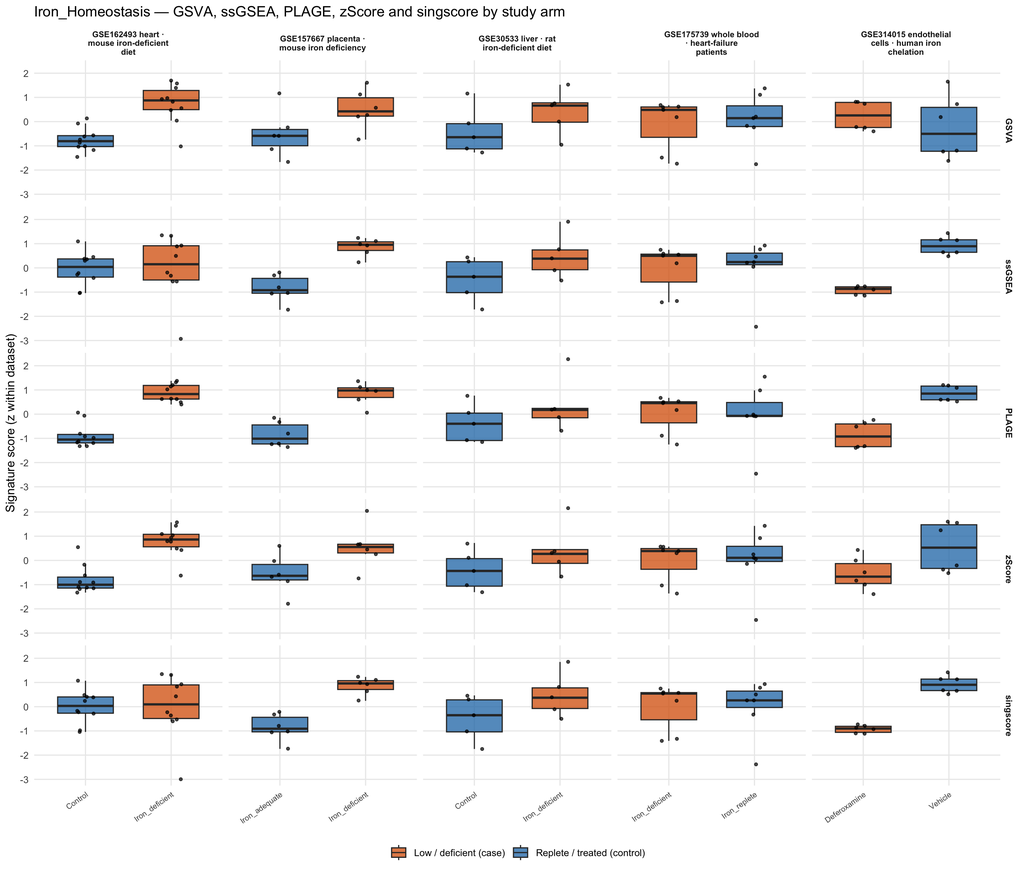

**ANOVA p-values.** *All arms* = one-way ANOVA across every study arm; *case vs control* = group effect after the listed covariates.

| Dataset | Role | Adjusted for | p (all arms) / p (case vs control) GSVA | p (all arms) / p (case vs control) ssGSEA | p (all arms) / p (case vs control) PLAGE | p (all arms) / p (case vs control) zScore | p (all arms) / p (case vs control) singscore |
| --- | --- | --- | --- | --- | --- | --- | --- |
| GSE162493 heart · mouse iron-deficient diet | Training | — | 9.4e-05 / 9.4e-05 | 0.861 / 0.861 | 3.8e-08 / 3.8e-08 | 1.3e-05 / 1.3e-05 | 0.960 / 0.960 |
| GSE157667 placenta · mouse iron deficiency | External | sex | 0.076 / 0.092 | 9.7e-05 / 1.7e-04 | 1.2e-04 / 2.1e-04 | 0.048 / 0.061 | 8.8e-05 / 1.5e-04 |
| GSE30533 liver · rat iron-deficient diet | External | — | 0.235 / 0.235 | 0.134 / 0.134 | 0.272 / 0.272 | 0.222 / 0.222 | 0.138 / 0.138 |
| GSE175739 whole blood · heart-failure patients | External | pair | 0.742 / 0.534 | 0.916 / 0.857 | 0.926 / 0.870 | 0.937 / 0.872 | 0.985 / 0.976 |
| GSE314015 endothelial cells · human iron chelation | External | cell_type | 0.415 / 0.114 | 7.7e-07 / 1.1e-06 | 5.6e-05 / 4.2e-09 | 0.051 / 5.1e-04 | 3.8e-07 / 4.9e-07 |

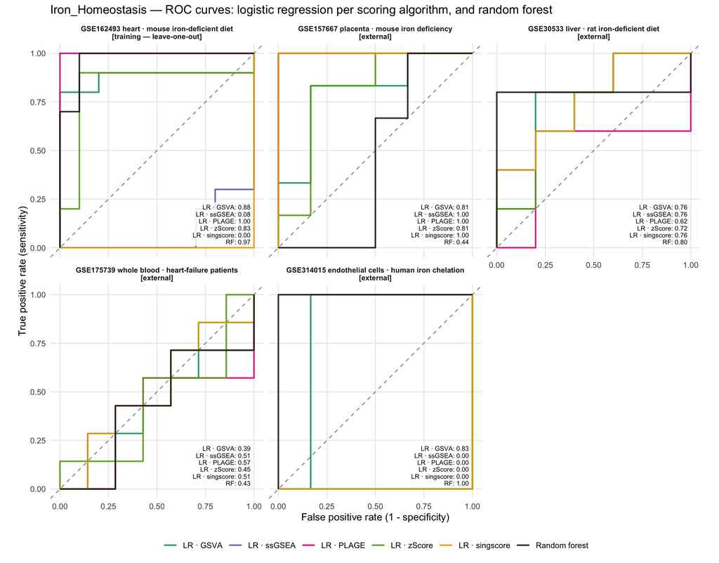

| Dataset | Validation | Model | AUC | 95% CI | Accuracy (p ≥ 0.5) | n case | n control |
| --- | --- | --- | --- | --- | --- | --- | --- |
| GSE162493 heart · mouse iron-deficient diet | Internal (in-sample) | Score · GSVA | 0.92 | 0.78–1.00 | — | 10 | 10 |
|  |  | Score · ssGSEA | 0.59 | 0.32–0.86 | — | 10 | 10 |
|  |  | Score · PLAGE | 1.00 | 1.00–1.00 | — | 10 | 10 |
|  |  | Score · zScore | 0.95 | 0.86–1.00 | — | 10 | 10 |
|  |  | Score · singscore | 0.55 | 0.27–0.83 | — | 10 | 10 |
|  | Internal (LOOCV) | LR · GSVA | 0.88 | 0.68–1.00 | 0.85 | 10 | 10 |
|  |  | LR · ssGSEA | 0.08 | 0.00–0.20 | 0.2 | 10 | 10 |
|  |  | LR · PLAGE | 1.00 | 1.00–1.00 | 1 | 10 | 10 |
|  |  | LR · zScore | 0.83 | 0.60–1.00 | 0.9 | 10 | 10 |
|  |  | LR · singscore | 0.00 | 0.00–0.00 | 0.05 | 10 | 10 |
|  |  | Random forest | 0.97 | 0.90–1.00 | 0.95 | 10 | 10 |
|  | Internal (leave-pair-out) | LR · GSVA | 0.92 | — | — | 10 | 10 |
|  |  | LR · ssGSEA | 0.26 | — | — | 10 | 10 |
|  |  | LR · PLAGE | 1.00 | — | — | 10 | 10 |
|  |  | LR · zScore | 0.95 | — | — | 10 | 10 |
|  |  | LR · singscore | 0.04 | — | — | 10 | 10 |
|  |  | Random forest | 0.99 | — | — | 10 | 10 |
| GSE157667 placenta · mouse iron deficiency | External | Score · GSVA | 0.81 | 0.53–1.00 | — | 6 | 6 |
|  |  | Score · ssGSEA | 1.00 | 1.00–1.00 | — | 6 | 6 |
|  |  | Score · PLAGE | 1.00 | 1.00–1.00 | — | 6 | 6 |
|  |  | Score · zScore | 0.81 | 0.52–1.00 | — | 6 | 6 |
|  |  | Score · singscore | 1.00 | 1.00–1.00 | — | 6 | 6 |
|  |  | LR · GSVA | 0.81 | 0.53–1.00 | 0.83 | 6 | 6 |
|  |  | LR · ssGSEA | 1.00 | 1.00–1.00 | 1 | 6 | 6 |
|  |  | LR · PLAGE | 1.00 | 1.00–1.00 | 0.92 | 6 | 6 |
|  |  | LR · zScore | 0.81 | 0.52–1.00 | 0.75 | 6 | 6 |
|  |  | LR · singscore | 1.00 | 1.00–1.00 | 1 | 6 | 6 |
|  |  | Random forest | 0.44 | 0.04–0.85 | 0.42 | 6 | 6 |
| GSE30533 liver · rat iron-deficient diet |  | Score · GSVA | 0.76 | 0.41–1.00 | — | 5 | 5 |
|  |  | Score · ssGSEA | 0.76 | 0.44–1.00 | — | 5 | 5 |
|  |  | Score · PLAGE | 0.72 | 0.37–1.00 | — | 5 | 5 |
|  |  | Score · zScore | 0.72 | 0.37–1.00 | — | 5 | 5 |
|  |  | Score · singscore | 0.76 | 0.44–1.00 | — | 5 | 5 |
|  |  | LR · GSVA | 0.76 | 0.41–1.00 | 0.8 | 5 | 5 |
|  |  | LR · ssGSEA | 0.76 | 0.44–1.00 | 0.6 | 5 | 5 |
|  |  | LR · PLAGE | 0.62 | 0.25–0.99 | 0.6 | 5 | 5 |
|  |  | LR · zScore | 0.72 | 0.37–1.00 | 0.6 | 5 | 5 |
|  |  | LR · singscore | 0.76 | 0.44–1.00 | 0.6 | 5 | 5 |
|  |  | Random forest | 0.80 | 0.41–1.00 | 0.7 | 5 | 5 |
| GSE175739 whole blood · heart-failure patients |  | Score · GSVA | 0.39 | 0.07–0.71 | — | 7 | 7 |
|  |  | Score · ssGSEA | 0.51 | 0.18–0.84 | — | 7 | 7 |
|  |  | Score · PLAGE | 0.53 | 0.20–0.86 | — | 7 | 7 |
|  |  | Score · zScore | 0.45 | 0.11–0.79 | — | 7 | 7 |
|  |  | Score · singscore | 0.51 | 0.18–0.84 | — | 7 | 7 |
|  |  | LR · GSVA | 0.39 | 0.07–0.71 | 0.43 | 7 | 7 |
|  |  | LR · ssGSEA | 0.51 | 0.18–0.84 | 0.43 | 7 | 7 |
|  |  | LR · PLAGE | 0.57 | 0.28–0.87 | 0.57 | 7 | 7 |
|  |  | LR · zScore | 0.45 | 0.11–0.79 | 0.57 | 7 | 7 |
|  |  | LR · singscore | 0.51 | 0.18–0.84 | 0.43 | 7 | 7 |
|  |  | Random forest | 0.43 | 0.09–0.76 | 0.5 | 7 | 7 |
| GSE314015 endothelial cells · human iron chelation |  | Score · GSVA | 0.83 | 0.51–1.00 | — | 6 | 6 |
|  |  | Score · ssGSEA | 0.00 | 0.00–0.00 | — | 6 | 6 |
|  |  | Score · PLAGE | 0.00 | 0.00–0.00 | — | 6 | 6 |
|  |  | Score · zScore | 0.00 | 0.00–0.00 | — | 6 | 6 |
|  |  | Score · singscore | 0.00 | 0.00–0.00 | — | 6 | 6 |
|  |  | LR · GSVA | 0.83 | 0.51–1.00 | 0.83 | 6 | 6 |
|  |  | LR · ssGSEA | 0.00 | 0.00–0.00 | 0 | 6 | 6 |
|  |  | LR · PLAGE | 0.00 | 0.00–0.00 | 0 | 6 | 6 |
|  |  | LR · zScore | 0.00 | 0.00–0.00 | 0 | 6 | 6 |
|  |  | LR · singscore | 0.00 | 0.00–0.00 | 0 | 6 | 6 |
|  |  | Random forest | 1.00 | 1.00–1.00 | 1 | 6 | 6 |

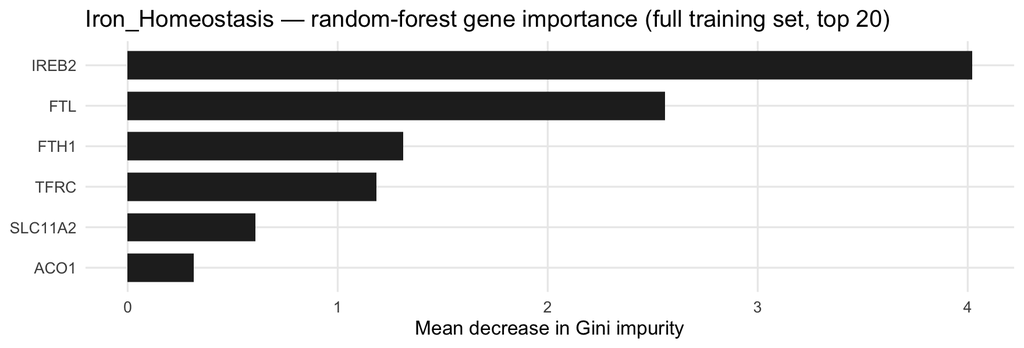

# Caveats for interpreting these results

- **Circular training sets.** `A_Retinol_Quiles_20` was derived from GSE299530 and `A_Retinol_GLM_43` from GSE134933 kidney; `B12_Cobalamin` was built from the cblX study (GSE161763); `Vitamin_K` was derived from GSE148011. Their internal (LOOCV) AUCs re-use the discovery data and are optimistic — the external columns are the real test.
- **Vitamin_K was replaced (2026-11-04).** The previous 50-gene list came from `~/Downloads/vitK_GSE148011_raw_counts.csv`, which merged GSE148011’s vitamin K and erastin arms across two gene annotations (45,323 vs 53,384 IDs): all 50 genes had **zero counts in every vitamin K-arm sample** and ~460,000 counts in the erastin arm, so the list captured the annotation mismatch, not vitamin K. The new `Vitamin_K` is the set of genes higher with the vitamin K precursor within the vitamin K arm only (`Scripts/derive_candidate_signatures.R`). That response is weak (no gene reaches 2-fold; top genes are cell-cycle genes; ~48% of genes have p < 0.1, suggesting a broad, possibly technical, shift), and the list was derived from the training set, so its internal AUC is circular — only the external columns test it. One vitamin K library (GSM4452216, 20 µM, replicate 2; ~20,000 reads) failed QC and was excluded.
- **Added datasets (2026-11-04) have their own limits.** GSE1063 is a ~590-gene cDNA array (symbols parsed from gene names), so most signatures barely overlap it. GSE344237 always gives L-carnitine together with resveratrol, and GSE272401 gives vitamins D and K together. GSE271941 compares two folic-acid doses (moderate vs fortified), not deficiency. GSE139892 uses a B6-pathway inhibitor rather than a deficient diet. GSE237219 has only 2 controls.
- **Second-pass datasets (2026-11-04).** B1 has only one usable dataset (benfotiamine in myotubes), so it is tested internally only. `B3_Niacin` has three genes, and CETP has no mouse ortholog, so only two genes are scored in the rodent datasets. GSE300498 has one sample per strain per diet. B5 is tested on a genetic CoA deficiency (Pank1/Pank2 knockout) and on CoA treatment, not on dietary pantothenate deficiency. GSE175739 (iron) and GSE29680 (omega-3) are **patient** cohorts (heart failure; Alzheimer’s disease), the first step towards the apply stage.
- **GWAS-based candidates.** `Vitamin_K_GWAS` uses the GWAS Catalog’s suggestive threshold (p ≤ 1e-5) because vitamin K measurement has no genome-wide significant hits. GWAS genes affect circulating nutrient levels; they need not change expression in nutrient-exposed tissue.
- **Small groups.** GSE161763 (3 vs 3), GSE99113 (2 vs 2), GSE190371 (2 vs 2), GSE134933 liver (3 vs 3) and GSE104164 (3 vs 4) give very wide confidence intervals; an AUC of 1.0 on four samples is weak evidence.
- **Deficiency vs. treatment.** The vitamin D, ATRA and vitamin K contrasts compare vehicle with pharmacological doses of the active compound in cell culture, which is not the same biology as dietary deficiency in vivo.
- **Cross-species mapping.** Rodent datasets are scored on human orthologs; mouse-only genes (e.g. most `Gm*` and `*Rik` genes in `Vitamin_K` and `A_Retinol_GLM_43`) have no ortholog and drop out (see each coverage table).
- **External calibration.** Each external dataset is z-scored on its own samples so that platforms are comparable. This uses no labels, but it assumes cases and controls are both present, so accuracy at the 0.5 threshold depends on each study’s case/control mix. AUC is unaffected.
- **Excluded datasets.** GSE266352 (LAMN vs colorectal metastases), GSE124395 (liver cell atlas), GSE246328 (NASH diet), GSE296260 (ccRCC), GSE143307 (methylation) and GSE271214/GSE271249 (RA-treated hESC, 2 per arm) have no usable nutrient contrast for expression-signature validation and were not processed.

# Reproducibility

Results tables written to `Reports/results/`: `auc_summary.csv`, `anova_summary.csv`, `signature_summary.csv`, `signature_scores.csv.gz`.